# Deep Learning — Assignment 4 — Score sheet

Fourth assignment for the 2024 Deep Learning course (NWI-IMC070) of the Radboud University.

Please enter your names and group number.**Names:**

**Group:**

**Instructions:**

- Fill in your names and the name of your group.
- Answer the questions and complete the code where necessary.
- Keep your answers brief, one or two sentences is usually enough.
- Re-run the whole notebook before you submit your work.
- Save the notebook as a PDF and submit that in Brightspace together with the `.ipynb` notebook file.
- The easiest way to make a PDF of your notebook is via File > Print Preview and then use your browser's print option to print to PDF.

## Objectives

In this assignment you will

1. Experiment with convolutional neural networks
2. Train a convolutional neural network on a speech dataset
3. Investigate the effect of dropout and batch normalization
4. Define and train a residual neural network

## Required software

If you haven't done so already, you will need to install the following additional libraries:

- `torch` and `torchvision` for PyTorch,
- `python_speech_features` to compute MFCC features.

All libraries can be installed with `pip install`.

```python
%matplotlib inline
import os
import numpy as np
import matplotlib.pyplot as plt
import torch
import time
from scipy.io import wavfile
from IPython import display

# Fix the seed, so outputs are exactly reproducible
torch.manual_seed(12345)

# Use the GPU if available
def detect_device():
    if torch.cuda.is_available():
        return torch.device("cuda")
    elif torch.backends.mps.is_available():
        return torch.device("mps")
    else:
        return torch.device("cpu")
device = detect_device()
```

## 4.1 Convolution and receptive fields (9 points)

We will first define some helper functions to plot the receptive field of a node in a network.

```python
def show_image(img, title=None, new_figure=True):
    if new_figure:
        plt.figure(figsize=(5, 5))
    im = plt.imshow(img, interpolation='none', aspect='equal', cmap='gray')
    ax = plt.gca();

    # plot pixel numbers and grid lines
    ax.set_xticks(np.arange(0, img.shape[1], 1))
    ax.set_yticks(np.arange(0, img.shape[0], 1))
    ax.set_xticklabels(np.arange(0, img.shape[1], 1))
    ax.set_yticklabels(np.arange(0, img.shape[0], 1))
    ax.set_xticks(np.arange(-.5, img.shape[1], 1), minor=True)
    ax.set_yticks(np.arange(-.5, img.shape[0], 1), minor=True)
    ax.grid(which='minor', color='gray', linestyle='-', linewidth=1.5)

    # hide axis outline
    for spine in ax.spines.values():
        spine.set_visible(False)

    if title is not None:
        plt.title(title)

# set all weights in the network to one,
# all biases to zero
def fill_weights_with_ones(network):
    for name, param in network.named_parameters():
        if 'weight' in name:
            param.data = torch.ones_like(param.data)
        elif 'bias' in name:
            param.data = torch.zeros_like(param.data)
    return network

def compute_receptive_field(network, input_size=(15, 15), binary=True):
    assert isinstance(network, torch.nn.Sequential), 'This only works with torch.nn.Sequential networks.'
    for layer in network:
        if not isinstance(layer, (torch.nn.Conv2d, torch.nn.AvgPool2d)):
            raise Exception('Sorry, this visualisation only works for Conv2d and AvgPool2d.')

    # initialize weights to ones, biases to zeros
    fill_weights_with_ones(network)

    # find the number of input and output channels
    input_channels = None
    output_channels = None
    for layer in network:
        if isinstance(layer, torch.nn.Conv2d):
            if input_channels is None:
                # first convolution layer
                input_channels = layer.in_channels
            output_channels = layer.out_channels
    if input_channels is None:
        input_channels = 1

    # first, we run the forward pass to compute the output shape give the input

    # PyTorch expects input shape [samples, channels, rows, columns]
    x = torch.zeros(1, input_channels, *input_size)
    x.requires_grad = True

    # forward pass: apply each layer in the network
    y = x
    y.retain_grad()
    ys = [y]
    for layer in network:
        y = layer(y)
        # keep track of the intermediate values so we can plot them later
        y.retain_grad()
        ys.append(y)

    # second, we run the backward pass to compute the receptive field

    # create gradient input: zeros everywhere, except for a single pixel
    y_grad = torch.zeros_like(y)
    # put a one somewhere in the middle of the output
    y_grad[0, 0, (y_grad.shape[2] - 1) // 2, (y_grad.shape[3] - 1) // 2] = 1

    # compute the gradients given this single one
    y.backward(y_grad)

    # receptive field is now in the gradient at each layer
    receptive_fields = []
    for y in ys:
        # the gradient for this layer shows us the receptive field
        receptive_field = y.grad
        if binary:
            receptive_field = receptive_field > 0
        receptive_fields.append(receptive_field)
    return receptive_fields

def plot_receptive_field(network, input_size=(15, 15), binary=True):
    receptive_fields = compute_receptive_field(network, input_size, binary)

    # plot the gradient at each layer
    plt.figure(figsize=(4 * len(receptive_fields), 4))
    for idx, receptive_field in enumerate(receptive_fields):
        plt.subplot(1, len(receptive_fields), idx + 1)
        # the last element of ys contains the output of the network
        if idx == len(receptive_fields) - 1:
            plot_title = 'output (%dx%d)' % (receptive_field.shape[2], receptive_field.shape[3])
        else:
            plot_title = 'layer %d input (%dx%d)' % (idx, receptive_field.shape[2], receptive_field.shape[3])
        # plot the image with the receptive field (sample 0, channel 0)
        show_image(receptive_field[0, 0], new_figure=False, title=plot_title)
        if not binary:
            plt.colorbar(fraction=0.047 * receptive_field.shape[0] / receptive_field.shape[1])

def receptive_field_size(network, input_size=(15, 15), binary=True):
    receptive_fields = compute_receptive_field(network, input_size, binary)
    return torch.count_nonzero(torch.flatten(receptive_fields[0][0,0]))
```

Using these functions, we can define a network and plot the receptive field of a pixel in the output.

**(a) Run the code to define a network with one 3×3 convolution layer and plot the images.**

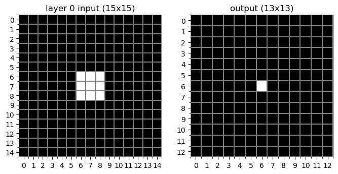

```python
net = torch.nn.Sequential(
    torch.nn.Conv2d(1, 1, kernel_size=(3, 3)),
)
plot_receptive_field(net, input_size=(15, 15))
```

Read these images as follows:

- On the left, you see the input size of the network (here: 15 x 15 pixels) and the receptive field for one pixel in the output.
- On the right, you see the output size of the network (here: 13 x 13 pixels).

To visualize the receptive field of this network, we used the following procedure:

- We selected one pixel of the output (shown as the white pixel in the center in the image on the right).
- We computed the gradient for this pixel and plotted the gradient with respect to the input (the image on the left).
- This shows you the receptive field of the network: the output for the pixel we selected depends on these 9 pixels in the input.

**4.1 b Add comment(b) Use this method to plot the receptive field of a pixel in the output of a convolution layer with a kernel size of 5×5. (1 point)**

*Grading:*

- 1 point for a fully correct implementation of the network and correct call to the function.

```python
### BEGIN ANSWER
net = torch.nn.Sequential(
    torch.nn.Conv2d(1, 1, kernel_size=(5, 5)),
)
plot_receptive_field(net, input_size=(15, 15))
### END ANSWER
```

[output not shown]

If you look at the result, you will see that two things have changed: the receptive field and the output size.

**4.1 c Add comment(c) How do the receptive field size and the output size depend on the kernel size? Give a formula. (1 point)**

Answer:

The receptive field is the same size as the kernel. The output size is input_size - kernel_size + 1

*Grading:*

- 1 point for a correct answer with a formula or other precise description.

### Counting the number of parameters

In the previous question, you saw how the receptive fields of a 3×3 convolution differs from a 5×5 kernel convolution. But this is not the only difference: there is also a difference in the number of parameters in the network.

We can count the number of parameters in the network by computing the number of elements (e.g., the weights and biases in a convolution kernel) in the parameter list of the PyTorch network.

We'll define a small helper function to do this:

```python
def print_parameter_count(network):
    # sum the number of elements in each parameter of the network
    count = sum([param.data.numel() for param in network.parameters()])
    print('%d parameters' % count)
```

**(d) Use the function to count the number of parameters for a 3×3 convolution.**

```
10 parameters
```

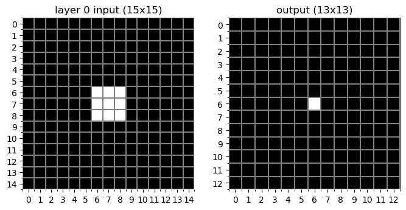

```python
net = torch.nn.Sequential(
    torch.nn.Conv2d(1, 1, kernel_size=(3, 3)),
)
plot_receptive_field(net, input_size=(15, 15))
print_parameter_count(net)
```

**4.1 e Add comment(e) Do the same to count the number of parameters for a 5×5 convolution. (1 point)**

*Grading:*

- 1 point for a correct implementation.

```python
### BEGIN ANSWER
net = torch.nn.Sequential(
    torch.nn.Conv2d(1, 1, kernel_size=(5, 5)),
)
plot_receptive_field(net, input_size=(15, 15))
print_parameter_count(net)
### END ANSWER
```

```
26 parameters
```

**4.1 f Add comment(f) Explain the results by showing how to *compute* the number of parameters for the 3×3 and 5×5 convolutions. (1 point)**

Answer:

For a $k \times k$ kernel, with $a$ input channels and $b$ output channels, there are $a b k^2$ weights and $b$ biases. For $k=3$ and a single channel this gives $3^2+1=10$, for $k=5$ this gives $5^2+1 = 26$.

*Grading:*

- 1 point for a correct derivation.
- It is okay to leave out the channels (that's the next question).
- 0 points if the bias is not included.

For these computations we used convolution layers with one input and one output channel.

We can also compute the results for a layer with a different number of channels.

**(g) Define a network with a 5×5 convolution, 2 input channels and 3 output channels. Print the number of parameters.**

```python
### BEGIN ANSWER
net = torch.nn.Sequential(
    torch.nn.Conv2d(2, 3, kernel_size=(5, 5)),
)
plot_receptive_field(net, input_size=(15, 15))
print_parameter_count(net)
### END ANSWER
```

```
153 parameters
```

**4.1 h Add comment(h) Show how to compute the number of parameters for this case. (1 point)**

Answer:

For a $k \times k$ kernel, with $a$ input channels and $b$ output channels, there are $a b k^2$ weights and $b$ biases. For $k=5$, $a=2$ and $b=3$ this gives this gives $2 \cdot 3 \cdot 5^2 + 3 = 153$.

*Grading:*

- 1 point for a correct derivation, including the input and output channels and the biases.

### Preserving the size of the input image

The PyTorch documentation for [`torch.nn.Conv2d`](https://pytorch.org/docs/stable/generated/torch.nn.Conv2d.html) describes the parameters that you can use to define a convolutional layer. We will explore some of those parameters in the next questions.

In the previous plot, you may have noticed that the output (13×13 pixels) was slightly smaller than the input (15×15 pixels).

**4.1 i Add comment(i) Define a network with a single 3×3 convolutional layer that produces an output that has the same size as the input. (1 point)**

Use 1 input and 1 output channel.

*Grading:*

- 1 point for a correct network.
- `padding=1` or `padding='same'` also works.

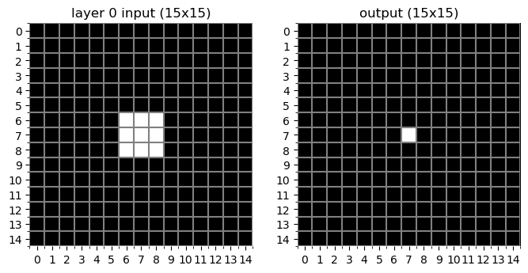

```python
### BEGIN ANSWER
net = torch.nn.Sequential(
    torch.nn.Conv2d(1, 1, kernel_size=(3, 3), padding=(1, 1)),
)
plot_receptive_field(net, input_size=(15, 15))
### END ANSWER
```

**4.1 j Add comment(j) Define a network with a single 5×5 convolutional layer that preserves the input size. (1 point)**

*Grading:*

- 1 point for a correct network.

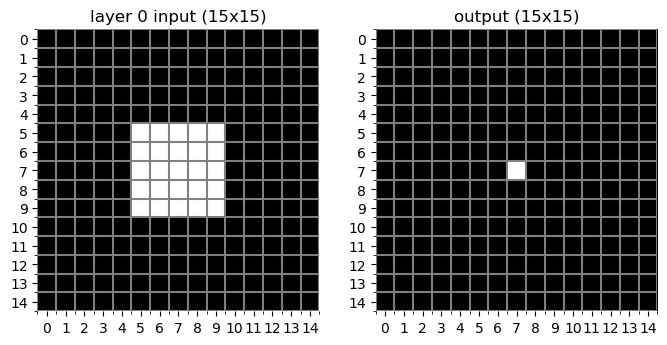

```python
### BEGIN ANSWER
net = torch.nn.Sequential(
    torch.nn.Conv2d(1, 1, kernel_size=(5, 5), padding=(2, 2)),
)
plot_receptive_field(net, input_size=(15, 15))
### END ANSWER
```

Play around with some other values to see how this parameter behaves.

### Multiple layers

As you have just seen, one way to increase the size of the receptive field is to use a larger convolution kernel. But another way is to use more than one convolution layer.

**4.1 k Add comment(k) Define a network with two 3×3 convolutions, preserving the image size. Show the receptive field and the number of parameters. (1 point)**

For this visualisation, do not use any activation functions, and use 1 channel everywhere.

*Grading:*

- 1 point for a correct implementation of the network.

```
Sequential(
  (0): Conv2d(1, 1, kernel_size=(3, 3), stride=(1, 1), padding=(1, 1))
  (1): Conv2d(1, 1, kernel_size=(3, 3), stride=(1, 1), padding=(1, 1))
)
20 parameters
```

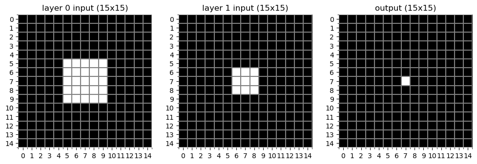

```python
### BEGIN ANSWER
net = torch.nn.Sequential(
    torch.nn.Conv2d(1, 1, kernel_size=(3, 3), padding=(1, 1)),
    torch.nn.Conv2d(1, 1, kernel_size=(3, 3), padding=(1, 1)),
)
### END ANSWER
print(net)
plot_receptive_field(net, input_size=(15, 15))
print_parameter_count(net)
```

Since we now have two layers, the visualization shows an extra image. From right to left, we have:

- Right: the output size and a single active pixel.
- Middle: the receptive field for the single output pixel between the first and second convolution.
- Left: the receptive field for the single output pixel in the input image.

We have now tried two ways to increase the receptive field size: increasing the kernel size, and using multiple layers.

**4.1 l Add comment(l) Compare the number of parameters required by the two options. Which one is more parameter-efficient? (1 point)**

Answer:

The receptive field is the same size for both networks (3×3 + 3×3 and 5×5). The network with two 3×3 kernels has 20 parameters (9+1 in two layers), while the 5×5 network has 26 parameters (25+1 in one layer). By stacking two smaller convolutions, we obtain the same receptive field with a smaller number of weights: the deep 3×3 network is more parameter-efficient.

*Grading:*

- 1 point for a correct comparison and conclusion.
- 0.5 point if the conclusion about which is better is missing or incorrect.

## 4.2 Variations on convolution (8 points)

### Pooling

We can also increase the size of the receptive field by using a pooling layer.

**4.2 a Add comment(a) Construct a network with a 3×3 convolution (preserving the input size) followed by a 2×2 average pooling. Plot the receptive field and print the number of parameters. (1 point)**

Use 1 input and 1 output channel.

*Grading:*

- 1 point for a correct implementation.

```
Sequential(
  (0): Conv2d(1, 1, kernel_size=(3, 3), stride=(1, 1), padding=(1, 1))
  (1): AvgPool2d(kernel_size=(2, 2), stride=(2, 2), padding=0)
)
10 parameters
```

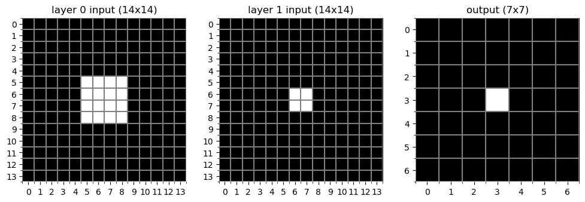

```python
### BEGIN ANSWER
net = torch.nn.Sequential(
    torch.nn.Conv2d(1, 1, kernel_size=(3, 3), padding=(1, 1)),
    torch.nn.AvgPool2d(kernel_size=(2, 2)),
)
### END ANSWER
print(net)
plot_receptive_field(net, input_size=(14, 14))
print_parameter_count(net)
```

**4.2 b Add comment(b) Explain the number of parameters in this convolution + pooling network. (1 point)**

Answer:

The pooling layer does not have any parameters. The convolution layer is the same as the 3×3 layer that we computed before: the number of parameters is 3×3 + 1 = 10.

*Grading:*

- 1 point for a correct answer.
- You don't have to repeat the formula here.

### Dilation

A third option to increase the receptive field is *dilation*.

**4.2 c Add comment(c) Define a network with 3×3 convolution with dilation that preserves the input size. (1 point)**

*Grading:*

- 1 point for a correct implementation.

```
Sequential(
  (0): Conv2d(1, 1, kernel_size=(3, 3), stride=(1, 1), padding=(2, 2), dilation=(2, 2))
)
10 parameters
```

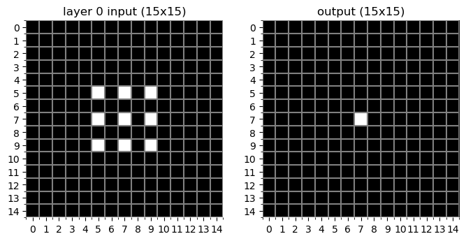

```python
### BEGIN ANSWER
net = torch.nn.Sequential(
    torch.nn.Conv2d(1, 1, kernel_size=(3, 3), padding=(2, 2), dilation=(2, 2)),
)
### END ANSWER
print(net)
plot_receptive_field(net, input_size=(15, 15))
print_parameter_count(net)
```

**4.2 d Add comment(d) Explain how dilation affects the receptive field. (1 point)**

Answer:

The dilation increases the area covered by the receptive field from 3×3 to 5×5 pixels. With the same number of parameters, the network convolution covers a larger area of the image.

*Grading:*

- 1 point for a correct answer.
- Saying that the receptive field "is 5×5 pixels" is acceptable.
- Saying that the receptive field still contains only 9 pixels is correct, but misses that they are spread out (0 points).

### Using strides

By default, convolution layers use a stride of 1.

**4.2 e Add comment(e) Change the network to use a stride of 2 and plot the result. (1 point)**

*Grading:*

- 1 point for a correct implementation of the network.

```
Storing rng state for 4.2e.
Restoring rng state for 4.2e.
Sequential(
  (0): Conv2d(1, 1, kernel_size=(3, 3), stride=(2, 2), padding=(1, 1))
)
10 parameters
```

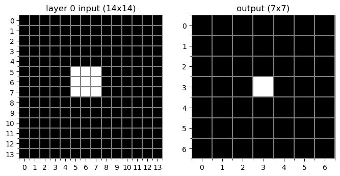

```python
### BEGIN ANSWER
net = torch.nn.Sequential(
    torch.nn.Conv2d(1, 1, kernel_size=(3, 3), padding=(1, 1), stride=(2, 2)),
)
### END ANSWER
print(net)
plot_receptive_field(net, input_size=(14, 14))
print_parameter_count(net)
```

**4.2 f Add comment(f) Explain the new output size and compare the result with that of pooling. (1 point)**

Answer:

Strided convolution has a downsampling effect similar to that of pooling: a stride of 2 reduces the output size by a factor 2.

*Grading:*

- 1 point for a correct answer.

**4.2 g Add comment(g) Explain how the stride affects the receptive field of this single convolution layer. (1 point)**

Answer:

It does not change the receptive field. The network still sees an area of 3×3 pixels when computing the value for an output pixel, it is just skipping over the image in larger steps.

*Grading:*

- 1 point for a correct answer.

**4.2 h Add comment(h) Explain the number of parameters for this network. (1 point)**

Answer:

Strides do not change the number of parameters, it just changes how the convolution moves over the image. The number of parameters is the same as for the earlier 3×3 layers.

*Grading:*

- 1 point for a correct answer.

## 4.3 Combining layers (7 points)

As you have seen, there are multiple ways to increase the receptive field. You can make interesting combinations by stacking multiple layers.

Let's try a few ways to make networks with a large receptive field. For each of the questions in this section:

- Create a network where a pixel in the output has a 9×9 receptive field.
- Use 3 input channels and 3 output channels in every layer.
- In convolution layers, try to preserve the input size as much as possible.

**4.3 a Add comment(a) Make a network with a single convolution that satisfies the above conditions. (1 point)**

*Grading:*

- 1 point for a correct implementation with the right amount of padding.
- 0 points if padding or kernel size is incorrect.

```
Sequential(
  (0): Conv2d(3, 3, kernel_size=(9, 9), stride=(1, 1), padding=(4, 4))
)
732 parameters
```

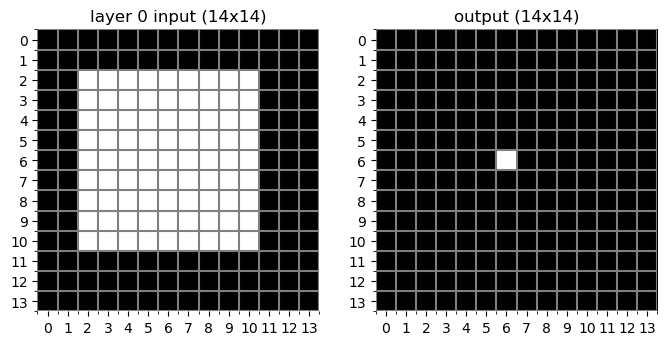

```python
### BEGIN ANSWER
net = torch.nn.Sequential(
    torch.nn.Conv2d(3, 3, kernel_size=(9, 9), padding=(4, 4)),
)
### END ANSWER
print(net)
plot_receptive_field(net, input_size=(14, 14))
print_parameter_count(net)
assert receptive_field_size(net) == 9*9, "Receptive field of output pixel should be a 9×9 square"
```

Many popular network architectures use a sequence of 3×3 convolutions.

**4.3 b Add comment(b) Use only 3×3 convolutions. (1 point)**

*Grading:*

- 1 point for a correct implementation with the right amount of padding in each layer.

```
Sequential(
  (0): Conv2d(3, 3, kernel_size=(3, 3), stride=(1, 1), padding=(1, 1))
  (1): Conv2d(3, 3, kernel_size=(3, 3), stride=(1, 1), padding=(1, 1))
  (2): Conv2d(3, 3, kernel_size=(3, 3), stride=(1, 1), padding=(1, 1))
  (3): Conv2d(3, 3, kernel_size=(3, 3), stride=(1, 1), padding=(1, 1))
)
336 parameters
```

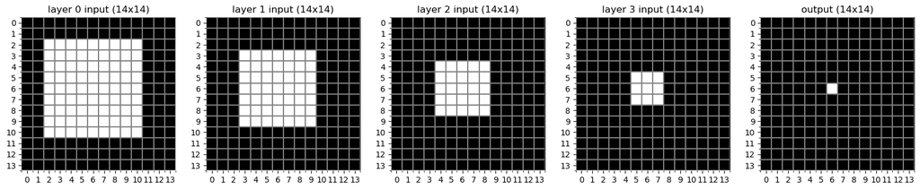

```python
### BEGIN ANSWER
net = torch.nn.Sequential(
    torch.nn.Conv2d(3, 3, kernel_size=(3, 3), padding=(1, 1)),
    torch.nn.Conv2d(3, 3, kernel_size=(3, 3), padding=(1, 1)),
    torch.nn.Conv2d(3, 3, kernel_size=(3, 3), padding=(1, 1)),
    torch.nn.Conv2d(3, 3, kernel_size=(3, 3), padding=(1, 1)),
)
### END ANSWER
print(net)
plot_receptive_field(net, input_size=(14, 14))
print_parameter_count(net)
assert receptive_field_size(net) == 9*9, "Receptive field of output pixel should be a 9×9 square"
```

**4.3 c Add comment(c) Use a 2×2 average pooling layer and a 2×2 convolution, in combination with one or more 3×3 convolutions. (1 point)**

*Grading:*

- 1 point for a correct implementation.
- Check the kernel size, the amount of padding, and the order of the layers.
- Note that for a pooling layer, it is impossible to set the padding to exactly keep the input size the same.
- Using padding=0 or padding=1 is acceptable for the second conv layer.

```
Sequential(
  (0): Conv2d(3, 3, kernel_size=(3, 3), stride=(1, 1), padding=(1, 1))
  (1): Conv2d(3, 3, kernel_size=(2, 2), stride=(1, 1), padding=(1, 1))
  (2): AvgPool2d(kernel_size=(2, 2), stride=(2, 2), padding=0)
  (3): Conv2d(3, 3, kernel_size=(3, 3), stride=(1, 1), padding=(1, 1))
)
207 parameters
```

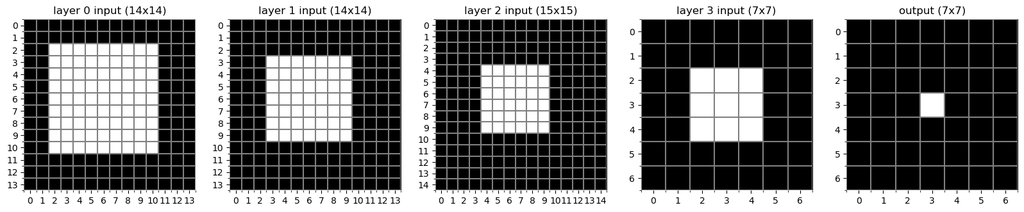

```python
### BEGIN ANSWER
net = torch.nn.Sequential(
    torch.nn.Conv2d(3, 3, kernel_size=(3, 3), padding=(1, 1)),
    torch.nn.Conv2d(3, 3, kernel_size=(2, 2), padding=(1, 1)),
    torch.nn.AvgPool2d(kernel_size=(2, 2)),
    torch.nn.Conv2d(3, 3, kernel_size=(3, 3), padding=(1, 1)),
)
### END ANSWER
print(net)
plot_receptive_field(net, input_size=(14, 14))
print_parameter_count(net)
assert receptive_field_size(net) == 9*9, "Receptive field of output pixel should be a 9×9 square"
```

**4.3 d Add comment(d) Copy the previous convolution + pooling network and replace the pooling layer with a strided convolution layer. (1 point)**

*Grading:*

- This question was incorrect (because it builds on the previous one). Be lenient when grading it.
- 1 point for any solution that uses a strided conv layer and that has the right size receptive field.

```
Sequential(
  (0): Conv2d(3, 3, kernel_size=(3, 3), stride=(1, 1), padding=(1, 1))
  (1): Conv2d(3, 3, kernel_size=(2, 2), stride=(1, 1))
  (2): Conv2d(3, 3, kernel_size=(2, 2), stride=(2, 2))
  (3): Conv2d(3, 3, kernel_size=(3, 3), stride=(1, 1), padding=(1, 1))
)
246 parameters
```

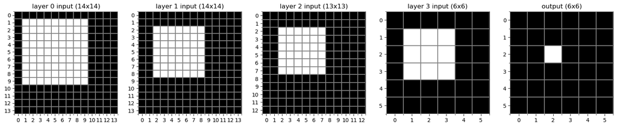

```python
### BEGIN ANSWER
net = torch.nn.Sequential(
    torch.nn.Conv2d(3, 3, kernel_size=(3, 3), padding=(1, 1)),
    torch.nn.Conv2d(3, 3, kernel_size=(2, 2), padding=(0, 0)),
    torch.nn.Conv2d(3, 3, kernel_size=(2, 2), padding=(0, 0), stride=(2, 2)),
    torch.nn.Conv2d(3, 3, kernel_size=(3, 3), padding=(1, 1)),
)
### END ANSWER
print(net)
plot_receptive_field(net, input_size=(14, 14))
print_parameter_count(net)
assert receptive_field_size(net) == 9*9, "Receptive field of output pixel should be a 9×9 square"
```

**4.3 e Add comment(e) Construct a network with exactly two 3×3 convolutions. Use dilation to get a receptive field of 9×9 pixels. (1 point)**

*Grading:*

- 1 point for a correct implementation.
- Check the kernel size, the dilation, the amount of padding, and the order of the layers.
- The receptive field must be a 9×9 square.
- Note: there are multiple solutions, depending on the amount of dilation used.

```
Sequential(
  (0): Conv2d(3, 3, kernel_size=(3, 3), stride=(1, 1), padding=(1, 1))
  (1): Conv2d(3, 3, kernel_size=(3, 3), stride=(1, 1), padding=(3, 3), dilation=(3, 3))
)
168 parameters
```

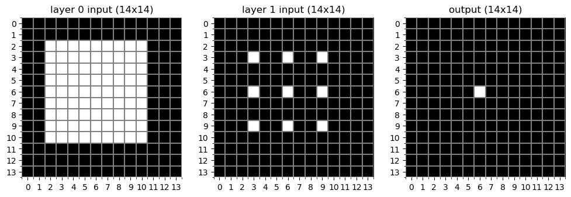

```python
### BEGIN ANSWER
net = torch.nn.Sequential(
    torch.nn.Conv2d(3, 3, kernel_size=(3, 3), padding=(1, 1)),
    torch.nn.Conv2d(3, 3, kernel_size=(3, 3), padding=(3, 3), dilation=(3, 3)),
)
### END ANSWER
print(net)
plot_receptive_field(net, input_size=(14, 14))
print_parameter_count(net)
assert receptive_field_size(net) == 9*9, "Receptive field of output pixel should be a 9×9 square"
```

**(f) For each of the methods, list the number of layers, the number of parameters, and the size of the output of the network:**

Answer:

[output not shown]

*Grading: No points.*

**4.3 g Add comment(g) Compare the methods in terms of the number of parameters. (1 point)**

Answer:

- The one-layer network with a big 9×9 kernel has the most parameters.
- The four-layer network with small 3×3 kernels is much more parameter-efficient.
- The network with pooling requires even fewer parameters: downsampling is a cheap way to increase the receptive field.
- The strided convolution requires a few more parameters than pooling, but still less than the four-layer network. The strides increase the receptive field.
- Dilation simulates large kernels, increasing the receptive field, but does not require as many parameters.

*Grading:*

- 1 point for a correct comparison.
- The answer should at least mention the model with the most and the model with the least parameters

**4.3 h Add comment(h) Compare the methods in terms of the output size. How much downsampling do they do? (1 point)**

Answer:

Downsampling means that the output size of the network is smaller than the input by a constant factor.

- The networks with pooling and strided convolutions include a downsampling step with factor 2. The output is 1/2 the size in each dimension.
- The other networks use convolutions without downsampling. The output has the same size/resolution as the input.

Note that padding is not the same as downsampling. If we try pooling/strides with a larger input size (e.g., 28×28), the output would be scaled proprotionally (e.g., 14×14). It changes the resolution of the output. On the other hand, padding does not change the resolution of the output: it only adds a constant number of pixels on each side.

*Grading:*

- 1 point for a correct comparison, observing that pooling and strided convolution downsample the images, while the other networks do not.

## 4.4 Padding in very deep networks (2 points)

Without padding, the output of a convolution is smaller than the input. This limits the depth of your network.

**(a) How often can you apply a 3×3 convolution to a 15×15 input image?**

```python
### BEGIN ANSWER
number_of_times = 7
### END ANSWER

# create a 15×15 input
x = torch.zeros(1, 1, 15, 15)
print('input size: %d×%d' % (x.shape[2], x.shape[3]))

# create a 3×3 convolution
conv = torch.nn.Conv2d(1, 1, kernel_size=(3, 3))

for n in range(number_of_times):
    # apply another convolution
    x = conv(x)
    print('layer %d, output size: %d×%d' % (n + 1, x.shape[2], x.shape[3]))
```

```
input size: 15×15
layer 1, output size: 13×13
layer 2, output size: 11×11
layer 3, output size: 9×9
layer 4, output size: 7×7
layer 5, output size: 5×5
layer 6, output size: 3×3
layer 7, output size: 1×1
```

Earlier in this assignment, you have used padding to address this problem. This seems ideal.

**(b) Copy the previous code, add some padding, and show that we can now have an infinite number of layers.**

(We are computer scientists and not mathematicians, so for the purpose of this question we'll consider 'infinite' to be equal to 25.)

```python
### BEGIN ANSWER
number_of_times = 25  #  ≈ infinity

# create a 15×15 input
x = torch.zeros(1, 1, 15, 15)
print('input size: %d×%d' % (x.shape[2], x.shape[3]))

# create a 3×3 convolution
conv = torch.nn.Conv2d(1, 1, kernel_size=(3, 3), padding=(1, 1))

for n in range(number_of_times):
    # apply another convolution
    x = conv(x)
    print('layer %d, output size: %d×%d' % (n + 1, x.shape[2], x.shape[3]))
### END ANSWER
```

```
input size: 15×15
layer 1, output size: 15×15
layer 2, output size: 15×15
layer 3, output size: 15×15
layer 4, output size: 15×15
layer 5, output size: 15×15
layer 6, output size: 15×15
layer 7, output size: 15×15
layer 8, output size: 15×15
layer 9, output size: 15×15
layer 10, output size: 15×15
layer 11, output size: 15×15
layer 12, output size: 15×15
layer 13, output size: 15×15
layer 14, output size: 15×15
layer 15, output size: 15×15
layer 16, output size: 15×15
layer 17, output size: 15×15
layer 18, output size: 15×15
layer 19, output size: 15×15
layer 20, output size: 15×15
layer 21, output size: 15×15
layer 22, output size: 15×15
layer 23, output size: 15×15
layer 24, output size: 15×15
layer 25, output size: 15×15
```

**(c) Does it really work like this? Have a look at the following experiment.**

- We simulate a convolution network with 25 convolution layers, with 3×3 kernels and the right amount of padding.
- We set the weights to 1/9 (so that the sum of the 3×3 kernel is equal to 1) and set the bias to zero.
- We give this network a 15×15-pixel input filled with ones.
- We plot the output of layers 5, 10, 15, 20, and 25.

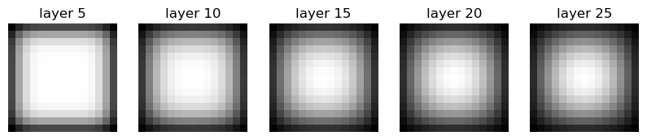

```python
# create a 15×15 input filled with ones
x = torch.ones(1, 1, 15, 15)

# create a 3×3 convolution
conv = torch.nn.Conv2d(1, 1, kernel_size=(3, 3), padding=(1, 1))

# set weights to 1/9 (= sum to one), bias to zero
conv.weight.data = torch.ones_like(conv.weight.data) / 9
conv.bias.data = torch.zeros_like(conv.bias.data)

plt.figure(figsize=(10, 2))
for n in range(1, 26):
    # apply another convolution
    x = conv(x)
    # print('layer %d, output size: %d×%d' % (n + 1, x.shape[2], x.shape[3]))
    if n % 5 == 0:
        plt.subplot(1, 5, n // 5)
        plt.imshow(x[0, 0].detach().numpy(), cmap='gray')
        plt.axis('off')
        plt.title('layer %d' % n)
```

**4.4 d Add comment(d) Explain the pattern that we see in the output of the final layers. How does this happen, and what does this mean for our very deep networks? (2 points)**

Answer:

What we see in these images are border effects. Padding makes the convolution work outside the image, preserving the image size, but it does so by adding zeros. Since these zeros are different from the pixel or feature values inside the image, the output near the borders will be based on slightly different input values than the pixels in the center of the image.

In the experiment here, we have inputs and kernels filled with constant values. In the center of the image, the output remains 1. At the borders, the zeros added by the padding lead to lower values, especially in later layers.

This effect is more pronounced at later layers of the network: this border artifacts introduced in layer 1 are used as the input for layer 2, where they affect the output a little bit further from the border et cetera. This means you can not have extremely deep networks without introducing these artifacts.

*Grading:*

- 1 point for explaining why this pattern happens,
- plus 1 point for a good argument about the network depth.

## 4.5 Spoken digits dataset (4 points)

Time for some practical experiments. In the previous assignments, we have used a dataset of images (FashionMNIST), and images are also a common application for CNNs. To mix things up, in this assignment we will investigate CNNs in a completely different domain: speech recognition.

The dataset we use is the free spoken digits dataset, which can be found on https://github.com/Jakobovski/free-spoken-digit-dataset. This dataset consists of the digits 0 to 9, spoken by different speakers. The data comes as .wav files.

**(a) Use the commands below (or a similar tool) to download the dataset. You can also use `git clone` to clone the repository mentioned above.**

```python
#! mkdir -p free-spoken-digit-dataset
#! wget -O - https://github.com/Jakobovski/free-spoken-digit-dataset/archive/refs/heads/master.tar.gz | tar xzv -C free-spoken-digit-dataset --strip-components=1
```

Below is a function to load the data. We pad/truncate each sample to the same length. The raw audio is usually stored in 16 bit integers, with a range -32768 to 32767, where 0 represents no signal. Before using the data, it should be normalized. A common approach is to make sure that the data is between -1 and 1, or that the data has zero-mean and unit-variance. Not all of these work well on this data, so later on, if your network doesn't seem to learn anything: try a different method to see if that works better.

**4.5 b Add comment(b) Update the below code to normalize the data to a reasonable range. (1 point)**

```python
samplerate = 8000
def load_waveform(file, size = 6000):
    samplerate, waveform = wavfile.read(file)
    # Take first 6000 samples from waveform. With a samplerate of 8000 that corresponds to 3/4 second
    # Pad with 0s if the file is shorter
    waveform = np.pad(waveform,(0,size))[0:size]
    # Normalize waveform
    ## BEGIN ANSWER
    # Subtract mean and divide by standard deviation
    waveform = waveform.astype(np.float32)
    waveform -= np.mean(waveform)
    waveform /= np.std(waveform)
    ## END ANSWER
    return waveform
```

The following code loads all .wav files in a directory, and makes it available in a pytorch dataset.

**(c) Load the data into a variable `data`.**

```python
class SpokenDigits(torch.utils.data.Dataset):
    def __init__(self, data_dir):
        digits_x = []
        digits_y = []
        for file in os.listdir(data_dir):
            if file.endswith(".wav"):
                waveform = load_waveform(os.path.join(data_dir, file))
                label = int(file[0])
                digits_x.append(waveform)
                digits_y.append(label)
        # convert to torch tensors
        self.x = torch.from_numpy(np.array(digits_x, dtype=np.float32))
        # add an extra dimension to represent the "channels" (we start with 1 channel of data)
        self.x = self.x.unsqueeze(1)
        self.y = torch.from_numpy(np.array(digits_y))

    def __len__(self):
        return len(self.x)

    def __getitem__(self, idx):
        return self.x[idx], self.y[idx]

## BEGIN ANSWER
data_dir = './free-spoken-digit-dataset/recordings/'
data = SpokenDigits(data_dir)
## END ANSWER

# Check if range of values is reasonable
assert abs(torch.mean(data[0][0])) < 1e-4, "Mean of data should be close to 0"
assert torch.max(abs(data[0][0])) < 10, "Data values should not be too large"
assert torch.max(abs(data[0][0])) >= 0.9, "Data values should not be too small"
```

**4.5 d Add comment(d) Describe the dataset: how many samples are there? How many features does each sample have? How many classes are there? (1 point)**

Note: You may compute the values, or just put in the numeric values.

*Grading:*

- 1 point for a correct answer. If you have the correct numbers but no code, that is also fine.
- 0.5 points if missing one of the 3 requested properties.

```python
## BEGIN ANSWER
number_of_samples = len(data)
number_of_features = len(data[0][0][0])
number_of_classes = len(np.unique([y for (x,y) in data]))
## END ANSWER
print('Number of samples:', number_of_samples)
print('Number of features:', number_of_features)
print('Number of classes:', number_of_classes)
```

```
Number of samples: 3000
Number of features: 6000
Number of classes: 10
```

Here is code to play samples from the dataset to give you an idea what it "looks" like.

Note: If this step doesn't work in your notebook, then you can ignore it.

```python
from IPython.display import Audio
def play(sample):
    print(f'Label: {sample[1]}')
    return Audio(sample[0][0].numpy(), rate=samplerate)
play(data[0])
```

```
Label: 2
```

[interactive chart not shown]

Before continuing, we split the dataset into a training and a validation set.

```python
train_fraction = 2/3
train_count = int(len(data) * train_fraction)
train_data, validation_data = torch.utils.data.random_split(data, [train_count, len(data) - train_count])
```

The code above uses 2/3 of the data for training.

**4.5 e Add comment(e) Discuss an advantage and disadvantage of using more of the data for training. (2 points)**

Answer:

Using more data for training can make the model more accurate.

But if more data is used for training, less remains for testing, and estimates about the generalization ability of the trained model becomes less certain and more noisy.

*Grading:*

- 1 point for the advantage, and 1 point for the disadvantage.

## 4.6 One-dimensional convolutional neural network (8 points)

We will now define a network architecture. We will use a combination of convolutional layers and pooling. Note that we use 1d convolution and pooling here, instead of the 2d operations used for images.

**4.6 a Add comment(a) Complete the network architecture. (2 points)**

```python
def build_net():
    return torch.nn.Sequential(
        torch.nn.Conv1d(1, 4, kernel_size=5),
        torch.nn.ReLU(),
        torch.nn.AvgPool1d(kernel_size=2, stride=2),
        ## BEGIN ANSWER
        torch.nn.Conv1d(4, 8, kernel_size=5),
        torch.nn.ReLU(),
        torch.nn.AvgPool1d(kernel_size=2, stride=2),
        torch.nn.Conv1d(8, 16, kernel_size=5),
        torch.nn.ReLU(),
        torch.nn.AvgPool1d(kernel_size=2, stride=2),
        torch.nn.Conv1d(16, 32, kernel_size=5),
        torch.nn.ReLU(),
        torch.nn.AvgPool1d(kernel_size=2, stride=2),
        ## END ANSWER
        torch.nn.Flatten(),
        torch.nn.Linear(11872, 128),
        torch.nn.ReLU(),
        torch.nn.Linear(128, 64),
        torch.nn.ReLU(),
        torch.nn.Linear(64, 10))
```

**4.6 b Add comment(b) The first fully connected layer has input dimension 11872, where does that number come from? (1 point)**

Answer:

When given an input of length $n$, a convolutional layer without padding and with kernel size $k$ produces an output of length $n-(k-1)$. A pooling layer with kernel size and stride 2 produces an output of length $\lfloor n / 2 \rfloor$.

The input has size $6000 \times 1$. After the first convolutional and pooling layers this becomes $2998 \times 4$. After the second convolutional and pooling layers this becomes $1497 \times 8$. After the third convolutional and pooling layers this becomes $746 \times 16$. After the fourth convolutional and pooling layers this becomes $371 \times 32$.

And the flatten layer turns this into a single vector of size $371 \cdot 32 = 11872$.

*Grading:*

- 1 point for a correct computation.
- 0 points for an argument such as "it is the output size of the last conv layer".

**4.6 c Add comment(c) How many parameters are there in the model? I.e. the total number of weights and biases. (1 point)**

*Grading:*

- 1 point for a correct answer.
- If you have the correct number but no code, that is also fine.

```python
## BEGIN ANSWER
net = build_net()
num_parameters = sum(p.nelement() for p in net.parameters())
print("Number of parameters:", num_parameters)
## END ANSWER
```

```
Number of parameters: 1532090
```

**4.6 d Add comment(d) Suppose that instead of using convolutions, we had used only fully connected layers, while keeping the number of features on each hidden layer the same. How many parameters would be needed in that case approximately? (1 point)**

Answer:

Replacing the convolutional layers with fully connected ones increases the number of parameters.

The first conv layers has an input of $6000\times 1$ and output of $(6000-4) \times 4$. A fully connected layer with the same input and output size would need $(6000\times 1 + 1) \times (6000-4) \times 4 = 143\,927\,984$ parameters.

Continuing for the other layers (see question B), we get a total of $1\,000\,723\,024$ parameters. This is over 600 times more than the convolutional network. Note that each fully connected layer has roughly the same number of parameters, since the input and output halve in size, while the number of input and output channels double.

*Grading:*

- The answer should be in the right order of magnitude.

We will once again need evaluation code and a training loop. The code below should be familiar from previous assignments.

```python
def accuracy(pred_y, true_y):
    correct = pred_y.argmax(dim=1) == true_y
    return int(correct.sum()) / len(true_y)

class Metrics:
    """Accumulate mean values of one or more metrics."""
    def __init__(self, n):
        self.count = 0
        self.sum = (0,) * n
    def add(self, count, *values):
        self.count += count
        self.sum = tuple(s + count * v for s,v in zip(self.sum,values))
    def mean(self):
        return tuple(s / self.count for s in self.sum)

def evaluate(net, test_data, batch_size=1000, loss_function=torch.nn.CrossEntropyLoss(), device=device):
    """
    Evaluate a model on the given dataset.
    Return loss, accuracy
    """
    # Note: we can use a large batch size for efficiency, it doesn't matter for the computed loss or accuracy
    test_loader = torch.utils.data.DataLoader(test_data, batch_size=batch_size)
    with torch.no_grad():
        net.eval()
        metrics = Metrics(2)
        for x, y in test_loader:
            x = x.to(device)
            y = y.to(device)
            pred_y = net(x)
            loss = loss_function(pred_y, y)
            acc = accuracy(pred_y, y)
            metrics.add(len(y), loss.item(), acc)
        return metrics.mean()
```

```python
class Plotter:
    """For plotting data in animation."""
    # Based on d2l.Animator
    def __init__(self, xlabel=None, ylabel=None, legend=None, xlim=None,
                 ylim=None, xscale='linear', yscale='linear',
                 fmts=('-', 'm--', 'g-.', 'r:'), nrows=1, ncols=1,
                 figsize=(3.5, 2.5)):
        """Defined in :numref:`sec_utils`"""
        # Incrementally plot multiple lines
        if legend is None:
            legend = []
        self.fig, self.axes = plt.subplots(nrows, ncols, figsize=figsize)
        if nrows * ncols == 1:
            self.axes = [self.axes, ]
        # Use a function to capture arguments
        def config_axes():
            axis = self.axes[0]
            axis.set_xlabel(xlabel), axis.set_ylabel(ylabel)
            axis.set_xscale(xscale), axis.set_yscale(yscale)
            axis.set_xlim(xlim),     axis.set_ylim(ylim)
            if legend:
                axis.legend(legend)
            axis.grid()
        self.config_axes = config_axes
        self.X, self.Y, self.fmts = None, None, fmts

    def add(self, x, y):
        # Add multiple data points into the figure
        if not hasattr(y, "__len__"):
            y = [y]
        n = len(y)
        if not hasattr(x, "__len__"):
            x = [x] * n
        if not self.X:
            self.X = [[] for _ in range(n)]
        if not self.Y:
            self.Y = [[] for _ in range(n)]
        for i, (a, b) in enumerate(zip(x, y)):
            if a is not None and b is not None:
                self.X[i].append(a)
                self.Y[i].append(b)
        self.axes[0].cla()
        for x, y, fmt in zip(self.X, self.Y, self.fmts):
            self.axes[0].plot(x, y, fmt)
        self.config_axes()
        display.display(self.fig)
        display.clear_output(wait=True)
```

```python
def train(net, train_data, validation_data, num_epochs, lr,
          batch_size=64, optimizer=torch.optim.Adam, device=device):
    """
    Train a network on the given training data.
    After every epoch compute validation loss and accuracy.
    """
    net.to(device)
    train_loader = torch.utils.data.DataLoader(train_data, batch_size=batch_size, shuffle=True)
    num_batches = len(train_loader)
    optimizer = optimizer(net.parameters(), lr=lr)
    loss_function = torch.nn.CrossEntropyLoss()
    plotter = Plotter(xlabel='epoch', xlim=[1, num_epochs],
                      legend=['train loss', 'train acc', 'val loss', 'val acc'])
    start_time = time.time()
    for epoch in range(num_epochs):
        # Sum of training loss, sum of training accuracy, no. of examples
        net.train()
        metrics = Metrics(2)
        for i, (x, y) in enumerate(train_loader):
            #timer.start()
            optimizer.zero_grad()
            x = x.to(device)
            y = y.to(device)
            pred_y = net(x)
            loss = loss_function(pred_y, y)
            loss.backward()
            optimizer.step()
            with torch.no_grad():
                acc = accuracy(pred_y, y)
                metrics.add(len(y), loss.item(), acc)
            if (i + 1) % (num_batches // 5) == 0 or i == num_batches - 1:
                train_loss, train_acc = metrics.mean()
                plotter.add(epoch + (i + 1) / num_batches, (train_loss, train_acc, None, None))
        val_loss, val_acc = evaluate(net, validation_data, loss_function=loss_function, device=device)
        plotter.add(epoch + 1, (None, None, val_loss, val_acc))
    train_loss, train_acc = metrics.mean()
    train_time = time.time() - start_time
    print(f'train loss {train_loss:.3f}, train acc {train_acc:.3f}, '
          f'val loss {val_loss:.3f}, val acc {val_acc:.3f}')
    print(f'{metrics.count * num_epochs / train_time:.1f} examples/sec '
          f'on {str(device)}')
```

The FashionMNIST dataset that we used before has 60000 training examples, of which we used only 1000. When using the entire FashionMNIST dataset, around 10 epochs are needed to train a convolutional neural network. How large is our training set this time? How would this affect the number of epochs that we need?

**4.6 e Add comment(e) How many epochs do you think are needed? (1 point)**

*Answer:*

This dataset has 3000 samples, only 1/20th of FashionMNIST, so we could expect to need more epochs if we want to do a similar number of iterations.

*Grading:*

- 1 point for a reasonable answer.
- The learning rate around 0.001 is okay, but 10 epochs is too short.
- Check if the network converges to a good result with these settings.

```python
## BEGIN ANSWER
# Many choices are possible, but we definitely need to increase the number of epochs
lr, num_epochs = 0.001, 30
## END ANSWER
```

**(f) Now train the network.**

```
train loss 0.060, train acc 0.978, val loss 1.350, val acc 0.702
647.1 examples/sec on cpu
```

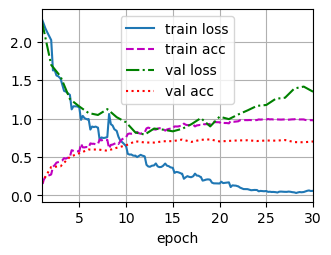

```python
train(build_net(), train_data, validation_data, num_epochs=num_epochs, lr=lr)
```

**4.6 g Add comment(g) Did the training converge? (2 point)**

**If the training has not converged, maybe you need to change the number of epochs and/or the learning rate.**

Answer:

You might need to experiment with learning rate and number of epochs.

*Grading:*

- 1 point if you have found a combination that converges to a good result.
- 1 point for correctly documenting all runs.

## 4.7 Questions and evaluation (6 points)

**4.7 a Add comment(a) Does the network look like it is overfitting or underfitting? Explain how see this. (1 point)**

Answer:

*Grading:*

- 1 point for a correct answer.
- 0 points if no explanation is given.
- The answer should mention the training and validation accuracy.

**4.7 b Add comment(b) Is what we have here a good classifier? Could it be used in a realistic application? Motivate your answer. (1 point)**

Answer:

*Grading:*

- 1 point for concluding the network is not good enough, with an argument.
- 0 points if there is no argument/explanation.
- The answer should not say that the network is good enough, unless it is explained why this is an acceptable performance in practice.

**4.7 c Add comment(c) Do you think there is enough training data compared to the dimensions of the data and the number of parameters? Motivate your answer. (1 point)**

Answer:

The network has 1 million parameters, which is much more than the number of data points. With strong regularization it is possible to train networks with more parameters than training points, but they still need a lot of data.

Another issue is the length of the input, since the input has 6000 features, there are also more features than samples. In such a setting even training a linear model is hard.

*Grading:*

- 1 point for a correct answer.
- 0 points if there is no motivation.
- Either of the explanations above is acceptable.

**4.7 d Add comment(d) How could the classifier be improved? Give at least 2 suggestions. (1 point)**

Answer:

Some ways to improve the classifier are:

- Adding regularization, for instance with weight decay or dropout
- Tweaking the network architecture (decreasing the number of layers, experimenting with the kernel size of the convolutions, etc.)
- Using more training data
- Use data augmentation
- Use a pre-trained or manual feature extractor

*Grading:*

- 0.5 point per good suggestion.
- 0 points if more than 2 suggestions are given and some are wrong.

**4.7 e Add comment(e) The free spoken digits datasets has recordings from several different speakers. Is the validation set accuracy a good measure of how well the trained network would perform for recognizing digits spoken by a new, unknown speaker? And if not, how could that be tested instead? (2 points)**

Answer:

Because the train/validation split is random, all speakers in the validation set are also very likely to be in the training set. So this is not representative of the case of recognizing a new speaker.

To test whether the network can recognize new speakers, a different train/validation split can be used, where the speakers are dividide between the two sets instead of the individual samples. In that way none of the speakers in the test set occur in the training set.

Because the number of speakers is quite small, the test set accuracy is still not guaranteed to give a good estimate of the generalization performance. So it can be helpful to do this multiple times with cross-validation.

*Grading:*

- 1 point for recognizing the problem,
- +1 point for proposing the solution.

## 4.8 Variations (8 points)

One way in which the training might be improved is with dropout or with batch normalization.

**4.8 a Add comment(a) Make a copy of the network architecture from 4.6a below, and add dropout. (1 point)**

*Grading:*

- 1 point for a correct and working implementation.
- Dropout after the convolution layers is also fine, and you don't need to have dropout after every layer.
- 0 points if you use dropout after the final layer.

```
train loss 0.190, train acc 0.928, val loss 0.811, val acc 0.791
663.5 examples/sec on cpu
```

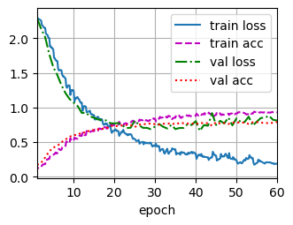

```python
def build_net_dropout():
    ## BEGIN ANSWER
    return torch.nn.Sequential(
        torch.nn.Conv1d(1, 4, kernel_size=5),
        torch.nn.ReLU(),
        torch.nn.AvgPool1d(kernel_size=2, stride=2),
        torch.nn.Conv1d(4, 8, kernel_size=5),
        torch.nn.ReLU(),
        torch.nn.AvgPool1d(kernel_size=2, stride=2),
        torch.nn.Conv1d(8, 16, kernel_size=5),
        torch.nn.ReLU(),
        torch.nn.AvgPool1d(kernel_size=2, stride=2),
        torch.nn.Conv1d(16, 32, kernel_size=5),
        torch.nn.ReLU(),
        torch.nn.AvgPool1d(kernel_size=2, stride=2),
        torch.nn.Flatten(),
        torch.nn.Linear(11872, 128),
        torch.nn.ReLU(),
        torch.nn.Dropout(0.5),
        torch.nn.Linear(128, 64),
        torch.nn.ReLU(),
        torch.nn.Dropout(0.5),
        torch.nn.Linear(64, 10))
    ## END ANSWER

train(build_net_dropout(), train_data, validation_data, num_epochs=2*num_epochs, lr=lr)
```

**4.8 b Add comment(b) How does dropout change the results? Does this match what you saw on the simple network last week? (1 point)**

Answer:

By introducing dropout, the network becomes slower to converge, and there is more variation in the accuracy and loss. But the final validation accuracy is higher while the train accuracy is lower. This means that we have reduced the amount of overfitting. This matches the results of assignment 3.

*Grading:*

- 1 point for a correct argument that considers both the training speed and the final test/train performance.

**4.8 c Add comment(c) Make a copy of the original network architecture, and add batch normalization to all convolutional and linear layers. (1 point)**

*Grading:*

- 1 point for a correct and working implementation.
- 0 points if your BatchNorm is placed after the ReLU activation.
- max 0.5 points if you use BatchNorm after the final layer.

```
train loss 0.002, train acc 1.000, val loss 0.476, val acc 0.856
637.2 examples/sec on cpu
```

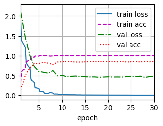

```python
def build_net_batchnorm():
    ## BEGIN ANSWER
    return torch.nn.Sequential(
        torch.nn.Conv1d(1, 4, kernel_size=5),
        torch.nn.BatchNorm1d(4),
        torch.nn.ReLU(),
        torch.nn.AvgPool1d(kernel_size=2, stride=2),
        torch.nn.Conv1d(4, 8, kernel_size=5),
        torch.nn.BatchNorm1d(8),
        torch.nn.ReLU(),
        torch.nn.AvgPool1d(kernel_size=2, stride=2),
        torch.nn.Conv1d(8, 16, kernel_size=5),
        torch.nn.BatchNorm1d(16),
        torch.nn.ReLU(),
        torch.nn.AvgPool1d(kernel_size=2, stride=2),
        torch.nn.Conv1d(16, 32, kernel_size=5),
        torch.nn.BatchNorm1d(32),
        torch.nn.ReLU(),
        torch.nn.AvgPool1d(kernel_size=2, stride=2),
        torch.nn.Flatten(),
        torch.nn.Linear(11872, 128),
        torch.nn.BatchNorm1d(128),
        torch.nn.ReLU(),
        torch.nn.Linear(128, 64),
        torch.nn.BatchNorm1d(64),
        torch.nn.ReLU(),
        torch.nn.Linear(64, 10))
    # Note: Put batchnorm before non-linearities like ReLU
    # Note: Don't put batchnorm after the last layer
    ## END ANSWER

train(build_net_batchnorm(), train_data, validation_data, num_epochs=num_epochs, lr=lr)
```

**4.8 d Add comment(d) How does batch normalization change the results? Does this match what you saw on the simple network last week? (1 point)**

Answer:

The network with batch normalization converges much faster than the baseline network without batch normalization, and it reaches a higher validation accuracy.

*Grading:*

- 1 point for correct observations on the convergence speed and the final performance.

### Residual network

We can also try to use a residual network.

Pytorch does not expose a general purpose block for residual connections. If you look at the [source code for ResNet vision model](https://pytorch.org/vision/0.8/_modules/torchvision/models/resnet.html), you will find the following definitions (slightly simplified):

```python
# From https://pytorch.org/vision/0.8/_modules/torchvision/models/resnet.html
# (simplified)

def conv3x3(in_channels, out_channels, stride=1):
    """3x3 convolution with padding"""
    return torch.nn.Conv2d(in_channels, out_channels, kernel_size=3, padding=1, stride=stride, bias=False)

def conv1x1(in_channels, out_channels, stride=1):
    """1x1 convolution, used for downsampling"""
    return torch.nn.Conv2d(in_channels, out_channels, kernel_size=1, stride=stride, bias=False)

class ResidualBlock2d(torch.nn.Module):
    def __init__(self, in_channels, channels, stride=1, downsample=None, norm_layer=None):
        super(ResidualBlock2d, self).__init__()
        if norm_layer is None:
            norm_layer = torch.nn.BatchNorm2d
        # Both self.conv1 and self.downsample layers downsample the input when stride != 1
        self.conv1 = conv3x3(in_channels, channels, stride)
        self.bn1 = norm_layer(channels)
        self.relu = torch.nn.ReLU(inplace=True)
        self.conv2 = conv3x3(channels, channels)
        self.bn2 = norm_layer(channels)
        if downsample is True:
            downsample = torch.nn.Sequential(conv1x1(in_channels, channels), norm_layer(channels))
        self.downsample = downsample
        self.stride = stride

    def forward(self, x):
        identity = x

        out = self.conv1(x)
        out = self.bn1(out)
        out = self.relu(out)

        out = self.conv2(out)
        out = self.bn2(out)

        if self.downsample is not None:
            identity = self.downsample(x)

        out += identity
        out = self.relu(out)

        return out
```

**4.8 e Add comment(e) Copy the `ResidualBlock2d` module below, and adapt it for 1d convolutions. Use a kernel size of 5 for the convolution layers. (2 points)**

Use residual blocks each containing two convolutional layers.

*Grading:*

- 2 points for a correct and working implementation.
- You should have changed the convolution and batch norm layers to 1d versions.
- Ideally, you would also have switched the kernel size from 3×3 to 5. (-1 point if not)
- If you did change the kernel size, you should have changed the padding from 1 to 2 as well, or use `padding='same'`. (-1 point if not)

```python
### BEGIN ANSWER
def conv5(in_channels, out_channels, stride=1):
    """size 5 convolution with padding"""
    return torch.nn.Conv1d(in_channels, out_channels, kernel_size=5, padding=2, stride=stride, bias=False)

def conv1(in_channels, out_channels, stride=1):
    """size 1 convolution"""
    return torch.nn.Conv1d(in_channels, out_channels, kernel_size=1, stride=stride, bias=False)

class ResidualBlock1d(torch.nn.Module):
    def __init__(self, in_channels, channels, stride=1, downsample=None, norm_layer=None):
        super(ResidualBlock1d, self).__init__()
        if norm_layer is None:
            norm_layer = torch.nn.BatchNorm1d
        self.conv1 = conv5(in_channels, channels, stride)
        self.bn1 = norm_layer(channels)
        self.relu = torch.nn.ReLU(inplace=True)
        self.conv2 = conv5(channels, channels)
        self.bn2 = norm_layer(channels)
        if downsample is True:
            downsample = torch.nn.Sequential(conv1(in_channels, channels), norm_layer(channels))
        self.downsample = downsample
        self.stride = stride

    def forward(self, x):
        identity = x

        out = self.conv1(x)
        out = self.bn1(out)
        out = self.relu(out)

        out = self.conv2(out)
        out = self.bn2(out)

        if self.downsample is not None:
            identity = self.downsample(x)

        out += identity
        out = self.relu(out)

        return out
### END ANSWER
```

**4.8 f Add comment(f) Make a copy of the network architecture from 4.6a, and replace the convolutions with residual blocks. (1 point)**

*Grading:*

- 1 point for a working network that replaces the original Conv1d with Residual blocks.
- Because the number of channels changes, the Residual blocks need a kernel_size=1 convolution.
- Because the Residual blocks use padding, the output size of the Flatten layer will be slightly larger than before.
- The residual block includes a ReLU activation, so that is no longer needed. (-0.5 points if those are still there)
- It is OK if you made slightly different implementation decisions, but it should look roughly the same.

```
train loss 0.000, train acc 1.000, val loss 0.258, val acc 0.939
306.5 examples/sec on cpu
```

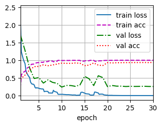

```python
def build_resnet():
    ## BEGIN ANSWER
    return torch.nn.Sequential(
        ResidualBlock1d(1, 4, downsample=True),
        torch.nn.AvgPool1d(kernel_size=2, stride=2),
        ResidualBlock1d(4, 8, downsample=True),
        torch.nn.AvgPool1d(kernel_size=2, stride=2),
        ResidualBlock1d(8, 16, downsample=True),
        torch.nn.AvgPool1d(kernel_size=2, stride=2),
        ResidualBlock1d(16, 32, downsample=True),
        torch.nn.AvgPool1d(kernel_size=2, stride=2),
        torch.nn.Flatten(),
        # we have a slightly different output size, because we use padding in the Residual blocks
        torch.nn.Linear(12000, 128),
        torch.nn.ReLU(),
        torch.nn.Linear(128, 64),
        torch.nn.ReLU(),
        torch.nn.Linear(64, 10))
    ## END ANSWER

## BEGIN ANSWER
train(build_resnet(), train_data, validation_data, num_epochs=num_epochs, lr=lr)
## END ANSWER
```

**4.8 g Add comment(g) How do residual connections change the results? (1 point)**

Answer:

- The network takes a lot longer to train, about twice as long. This happens because the number of convolution layers is larger, because each residual block contains 2 conv5 layers (and a conv1 layer, which is fast).
- The validation accuracy is higher than before. This is probably a result of having a more complex, deeper network.

*Grading:*

- 1 point for observing the performance improvement and the increased runtime.

## 4.9 Feature extraction (5 points)

Given enough training data a deep neural network can learn to extract features from raw data like audio and images. However, in some cases it is still necessary to do manual feature extraction, in particular when working with smaller datasets like this one. For speech recognition, a popular class of features are [MFCCs](https://en.wikipedia.org/wiki/Mel-frequency_cepstrum).

Here is code to extract these features. You will need to install the `python_speech_features` first.

```python
from python_speech_features import mfcc

def load_waveform_mfcc(file, size = 6000):
    samplerate, waveform = wavfile.read(file)
    waveform = np.pad(waveform,(0,size))[0:size] / 32768
    return np.transpose(mfcc(waveform, samplerate))
```

**4.9 a Add comment(a) Implement a variation of the dataset that uses these features. (2 points)**

*Grading:

- 2 points for a correct implementation based on the earlier `SpokenDigits` dataset, that uses the `load_waveform_mfcc` function to load the data.

```python
class SpokenDigitsMFCC(torch.utils.data.Dataset):
    ## BEGIN ANSWER
    def __init__(self, data_dir):
        digits_x = []
        digits_y = []
        for file in os.listdir(data_dir):
            if file.endswith(".wav"):
                waveform = load_waveform_mfcc(os.path.join(data_dir, file))
                label = int(file[0])
                digits_x.append(waveform)
                digits_y.append(label)
        # convert to torch tensors
        self.x = torch.from_numpy(np.array(digits_x, dtype=np.float32))
        self.y = torch.from_numpy(np.array(digits_y))
    def __len__(self):
        return len(self.x)
    def __getitem__(self, idx):
        return self.x[idx], self.y[idx]
    ## END ANSWER

data_mfcc = SpokenDigitsMFCC(data_dir) # TODO: your data directory here
train_count_mfcc = int(len(data_mfcc) * train_fraction)
train_data_mfcc, validation_data_mfcc = torch.utils.data.random_split(data_mfcc, [train_count_mfcc, len(data_mfcc)-train_count_mfcc])

assert train_data_mfcc[0][0].shape == torch.Size([13,74]), "There is something wrong with the SpokenDigitsMFCC dataset"
```

The MFCC features will have 13 channels instead of 1 (the `unsqueeze` operation is not needed).

**4.9 b Add comment(b) Inspect the shape of the data, and define a new network architecture that accepts data with this shape. (1 point)**

*Grading:*

- 1 point for an correct and working implementation of the network.
- The number of channels in the input has changed, so change your first layer accordingly.
- Change the Linear layer directly after Flatten: because the MFCC features are computed over small times windows, the samples are shorter.

```python
## BEGIN ANSWER
number_of_samples = len(data_mfcc)
data_shape = data_mfcc[0][0].shape
number_of_classes = len(np.unique([y for (x,y) in data_mfcc]))
print('Number of samples:', number_of_samples)
print('Shape of samples:', data_shape)
print('Number of classes:', number_of_classes)

def build_net_mfcc():
    return torch.nn.Sequential(
        # there are now 13 input channels instead of 1
        torch.nn.Conv1d(13, 32, kernel_size=5),
        torch.nn.ReLU(),
        torch.nn.AvgPool1d(kernel_size=2, stride=2),
        torch.nn.Conv1d(32, 64, kernel_size=5),
        torch.nn.ReLU(),
        torch.nn.AvgPool1d(kernel_size=2, stride=2),
        torch.nn.Conv1d(64, 128, kernel_size=5),
        torch.nn.ReLU(),
        torch.nn.Flatten(),
        # the samples are shorter, so the input here is smaller
        torch.nn.Linear(1408, 128),
        torch.nn.ReLU(),
        torch.nn.Linear(128, 64),
        torch.nn.ReLU(),
        torch.nn.Linear(64, 10))
## END ANSWER
```

```
Number of samples: 3000
Shape of samples: torch.Size([13, 74])
Number of classes: 10
```

**4.9 c Add comment(c) Train the network with the MFCC features. (1 point)**

*Grading:*

- 1 point for running your network until it converges.

```
train loss 0.006, train acc 0.999, val loss 0.082, val acc 0.983
2290.6 examples/sec on cpu
```

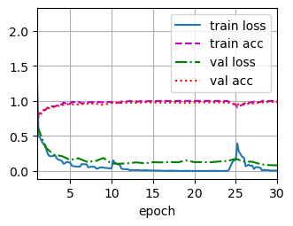

```python
## BEGIN ANSWER
train(build_net_mfcc(), train_data_mfcc, validation_data_mfcc, num_epochs=num_epochs, lr=lr)
## END ANSWER
```

**4.9 d Add comment(d) What would be needed to get a fully neural network approach to work as well as MFCC features? (1 point)**

Answer:

- A neural network needs enough training data to compete with MFCC features. If another dataset is available, a network could be pretrained on that other dataset. If only unlabeled data is available an unsupervised pre-training method such as wav2vec can be used.
- You can also see that the residual network performed quite well, so perhaps a change in architecture (increasing the complexity of the network) might also improve results.
- There are other advanced architectures, such as recurrent neural networks, that you could try.

*Grading:*

- 1 point for a good suggestion.
- 0.5 points for "get more data" without further explanation
- 0 points for suggesting things like "add more layers" or "train longer" without further explanation

## The end

Well done! Please double check the instructions at the top before you submit your results.

*This assignment has 57 points.* Version 3e03fe7 / 2024-09-24

## Score form

Download the scores as a text file